# Lecture 1 - Genetic Algorithms (GAs) for function optimization

February 12, 2024

## Let’s get started

- What are the genetic algorithms (GAs)?

## Introduction to GAs

**Overview:** Genetic algorithms (GAs) are optimization methods inspired by natural selection and genetics. They are used to solve optimization problems by evolving a population of candidate solutions.

**Key concepts:**

- **Population**: Set of possible solutions.
- **Fitness**: A measure of how good each solution is.
- **Selection**: Choosing individuals for reproduction.
- **Crossover**: Combining parts of two solutions to create a new solution.
- **Mutation**: Randomly altering a solution.

## Problem to solve

**Objective:** We aim to optimize the quadratic function \(f(x) = x^2 - 4x + 4\), minimizing the value of \(f(x)\).

**Function:** \[ f(x) = x^2 - 4x + 4 \]

## Initialize population

We begin by creating an initial population of three individuals: \(x_1 = 1\), \(x_2 = 3\), and \(x_3 = 0\).

```r
population <- c(1, 3, 0)
population
```

```
## [1] 1 3 0
```

## Evaluate fitness

**Fitness function:** The fitness of an individual is how well it minimizes the function \(f(x)\).

For each individual, calculate \(f(x)\): \[ f(x) = x^2 - 4x + 4 \]

```r
f <- function(x) {
    x^2 - 4*x + 4
}

# we calculate fitness
fitness <- f(population)
fitness
```

```
## [1] 1 1 4
```

## Visualizing the **fitness function**

Let’s plot the quadratic function \(f(x)\) to visualize the optimization landscape.

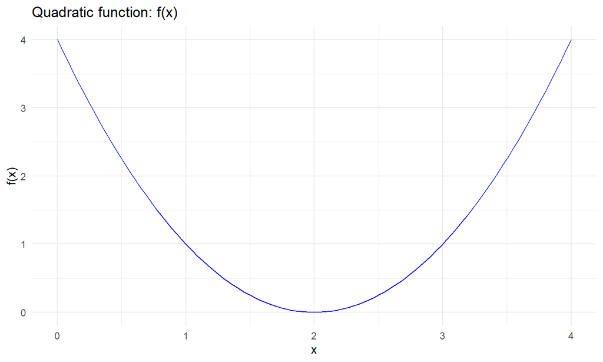

## Selection

We select individuals for crossover based on fitness. Lower fitness values are better in this case, so we select \(x_1 = 1\) and \(x_2 = 3\).

```r
# w select the parents with the best fitness (lowest values)
selected_parents <- population[order(fitness)][1:2]
selected_parents
```

```
## [1] 1 3
```

## Crossover and mutation

**Crossover:** Combines the genes (values) of two parents to create offspring.

**Mutation:** Introduces random changes to avoid local minima.

```r
# perform crossover (simple example: no change in this step)
offspring <- selected_parents

# introduce mutation with a small probability (no mutation for this example)
mutated_offspring <- offspring
mutated_offspring
```

```
## [1] 1 3
```

## Replacement

We replace one of the individuals in the population with the offspring to form a new population.

```r
# replace the least fit individual in the population with one of the offspring
new_population <- c(selected_parents, population[which.min(fitness)])
new_population
```

```
## [1] 1 3 1
```

## Iteration and convergence

The process is repeated over multiple generations. The population evolves over time, approaching the optimal solution, to eventually reach it.

## Finding the optimal solution

**Theoretical optimal point:**

The minimum of the quadratic function occurs at: \[ x = \frac{-b}{2a} = 2 \] The corresponding function value is \(f(2) = 0\).

```r
# calculate the optimal point
optimal_x <- -(-4) / (2 * 1)
optimal_y <- f(optimal_x)
c(optimal_x, optimal_y)
```

```
## [1] 2 0
```

## Conclusion

**Key Takeaways:**

- Genetic algorithms can be applied to solve optimization problems.
- Through selection, crossover, and mutation, a population evolves to find the optimal solution.
- This approach is effective for problems where traditional optimization methods might struggle.

**Further Applications:**

- Neural network optimization.
- Solving NP-hard problems like the traveling salesman problem.
- Automated design and engineering.

## Thank You!

Any questions?